# NOAA Stormdata Tracking between 1950-2011

## Synopsis

In this report we are analyzing the U.S. National Oceanic and Atmospheric Administration’s (NOAA) storm database. The database has tracking for events in the US 50 states as well as 22 other locations like US territorities (e.g. Guam, American Samoa) which will be ignored for this analysis.

Tornados, heat, and thunderstorm (TSTM) wind are the top 3 total injury plus death events over the measured 61 year period. Interestingly, the average number of injuries and average fatalities for all “heat-related” events and hurricane/typhoon stand out above the baseline data. This means that on average, when these events occur, they injure or kill more people than even tornados.

The top 3 economic impact events are: flood, hurricane/typhoon, and tornado. Data shows that the majority of economic loss is in property. Temperature related events (drought, extreme heat/cold, frost) all show higher crop damage than property damage - this intuitively makes sense. The catastropic events like flood, hurricane/typhoon, tornados are the ones that cause the largest property damage.

## Data Processing

```r
library(lubridate)
library(ggplot2)
library(dplyr)
library(data.table)
library(tidyr)
## loading for US State Facts and Figures
library(datasets)

## output taller and wider graphs in knitr
## opts_chunk$set(out.width='900px',out.height = '650px', dpi=200)

if (!file.exists("./data")) {
    dir.create("./data")
}
```

Download, unzip, and read in the data. This was done on Windows7 OS, so downloaded in ‘wb’ mode.

```r
fileurl <- "https://d396qusza40orc.cloudfront.net/repdata%2Fdata%2FStormData.csv.bz2"
download.file(fileurl, destfile = "./data/repdata%2Fdata%2FStormData.csv.bz2", mode = 'wb')

data <- read.csv("./data/repdata%2Fdata%2FStormData.csv.bz2", stringsAsFactors = FALSE)
```

Take a preliminary look at the data.

```r
str(data)
```

```
## 'data.frame':    902297 obs. of  37 variables:
##  $ STATE__   : num  1 1 1 1 1 1 1 1 1 1 ...
##  $ BGN_DATE  : chr  "4/18/1950 0:00:00" "4/18/1950 0:00:00" "2/20/1951 0:00:00" "6/8/1951 0:00:00" ...
##  $ BGN_TIME  : chr  "0130" "0145" "1600" "0900" ...
##  $ TIME_ZONE : chr  "CST" "CST" "CST" "CST" ...
##  $ COUNTY    : num  97 3 57 89 43 77 9 123 125 57 ...
##  $ COUNTYNAME: chr  "MOBILE" "BALDWIN" "FAYETTE" "MADISON" ...
##  $ STATE     : chr  "AL" "AL" "AL" "AL" ...
##  $ EVTYPE    : chr  "TORNADO" "TORNADO" "TORNADO" "TORNADO" ...
##  $ BGN_RANGE : num  0 0 0 0 0 0 0 0 0 0 ...
##  $ BGN_AZI   : chr  "" "" "" "" ...
##  $ BGN_LOCATI: chr  "" "" "" "" ...
##  $ END_DATE  : chr  "" "" "" "" ...
##  $ END_TIME  : chr  "" "" "" "" ...
##  $ COUNTY_END: num  0 0 0 0 0 0 0 0 0 0 ...
```

[output cut: 23 more lines]

```r
head(data)
```

```
##   STATE__           BGN_DATE BGN_TIME TIME_ZONE COUNTY COUNTYNAME STATE
## 1       1  4/18/1950 0:00:00     0130       CST     97     MOBILE    AL
## 2       1  4/18/1950 0:00:00     0145       CST      3    BALDWIN    AL
## 3       1  2/20/1951 0:00:00     1600       CST     57    FAYETTE    AL
## 4       1   6/8/1951 0:00:00     0900       CST     89    MADISON    AL
## 5       1 11/15/1951 0:00:00     1500       CST     43    CULLMAN    AL
## 6       1 11/15/1951 0:00:00     2000       CST     77 LAUDERDALE    AL
##    EVTYPE BGN_RANGE BGN_AZI BGN_LOCATI END_DATE END_TIME COUNTY_END
## 1 TORNADO         0                                               0
## 2 TORNADO         0                                               0
## 3 TORNADO         0                                               0
## 4 TORNADO         0                                               0
## 5 TORNADO         0                                               0
## 6 TORNADO         0                                               0
##   COUNTYENDN END_RANGE END_AZI END_LOCATI LENGTH WIDTH F MAG FATALITIES
```

[output cut: 20 more lines]

```r
summary(data)
```

```
##     STATE__       BGN_DATE           BGN_TIME          TIME_ZONE
##  Min.   : 1.0   Length:902297      Length:902297      Length:902297
##  1st Qu.:19.0   Class :character   Class :character   Class :character
##  Median :30.0   Mode  :character   Mode  :character   Mode  :character
##  Mean   :31.2
##  3rd Qu.:45.0
##  Max.   :95.0
##
##      COUNTY       COUNTYNAME           STATE              EVTYPE
##  Min.   :  0.0   Length:902297      Length:902297      Length:902297
##  1st Qu.: 31.0   Class :character   Class :character   Class :character
##  Median : 75.0   Mode  :character   Mode  :character   Mode  :character
##  Mean   :100.6
##  3rd Qu.:131.0
##  Max.   :873.0
##
##    BGN_RANGE          BGN_AZI           BGN_LOCATI
##  Min.   :   0.000   Length:902297      Length:902297
##  1st Qu.:   0.000   Class :character   Class :character
##  Median :   0.000   Mode  :character   Mode  :character
##  Mean   :   1.484
##  3rd Qu.:   1.000
##  Max.   :3749.000
##
##    END_DATE           END_TIME           COUNTY_END COUNTYENDN
##  Length:902297      Length:902297      Min.   :0    Mode:logical
##  Class :character   Class :character   1st Qu.:0    NA's:902297
##  Mode  :character   Mode  :character   Median :0
##                                        Mean   :0
##                                        3rd Qu.:0
##                                        Max.   :0
##
##    END_RANGE          END_AZI           END_LOCATI
##  Min.   :  0.0000   Length:902297      Length:902297
##  1st Qu.:  0.0000   Class :character   Class :character
##  Median :  0.0000   Mode  :character   Mode  :character
##  Mean   :  0.9862
##  3rd Qu.:  0.0000
##  Max.   :925.0000
##
```

[output cut: 33 more lines]

```
##  Min.   :-14451   Min.   :   0   Min.   :-14455   Length:902297
##  1st Qu.:  7247   1st Qu.:   0   1st Qu.:     0   Class :character
##  Median :  8707   Median :   0   Median :     0   Mode  :character
##  Mean   :  6940   Mean   :1452   Mean   :  3509
##  3rd Qu.:  9605   3rd Qu.:3549   3rd Qu.:  8735
##  Max.   : 17124   Max.   :9706   Max.   :106220
##                   NA's   :40
##      REFNUM
##  Min.   :     1
##  1st Qu.:225575
##  Median :451149
##  Mean   :451149
##  3rd Qu.:676723
##  Max.   :902297
##
```

This was moderately helpful, we are interested in health and economic impacts by events. I see the columns of interest.

Let’s start to explore the data in the columns, here are some basic questions I have.

```r
length(unique(data$EVTYPE)) -> disaster.type.count
print(disaster.type.count)
```

```
## [1] 985
```

```r
range(data$FATALITIES) -> max.death.count
print(max.death.count)
```

```
## [1]   0 583
```

```r
range(data$INJURIES) -> max.injury.count
print(max.injury.count)
```

```
## [1]    0 1700
```

```r
length(unique(data$STATE)) -> states.impacted.count
print(states.impacted.count)
```

```
## [1] 72
```

```r
unique(data$STATE) -> states.impacted
setdiff(states.impacted, state.abb) -> impacted.outside.50.states
```

There are 22 locations outside the US 50 states that are included in this data set. I see Guam, Puerto Rico, Virgin Islands….several others I don’t recognize. For this analysis we are asked to look at just the United States, which I interpret as just the 50 US states. We will need to remove all of the extra locations in the data, however, “DC” appears to be Washington, DC, so I will include that one.

## Results

convert from data.frame to my preferred data.table.

```r
dt_data <- data.table(data)

## check for NA values
sum(is.na(dt_data$INJURIES))
```

```
## [1] 0
```

```r
sum(is.na(dt_data$FATALITIES))
```

```
## [1] 0
```

There are no NA rows….good!

### Health impact analysis

Calculate: 1) Remove non-US states. Keep Washington, DC. 2) The total sum and averages of deaths and injuries by event type. 3) Also calculate a total sum of fatal+injure by event type.

```r
impacted.outside.50.states.no.DC <- impacted.outside.50.states[!impacted.outside.50.states %in%
                                                 "DC"]

dt_data_nonUS_removed <- dt_data[which(!dt_data$STATE %in%
                                           impacted.outside.50.states.no.DC),]

dt_data_sums <- dt_data_nonUS_removed[,.(sum.fatalities=sum(FATALITIES),
                                         avg.fatalities=mean(FATALITIES),
                                          sum.injuries=sum(INJURIES), avg.injuries=mean(INJURIES),
                                          sum.fatal.or.injure=sum(FATALITIES,INJURIES)),
                                       by=EVTYPE][order(-sum.fatal.or.injure)][sum.fatal.or.injure >= 100]

dt_data_sums
```

```
##                      EVTYPE sum.fatalities avg.fatalities sum.injuries
##  1:                 TORNADO           5633   9.289861e-02        91346
##  2:          EXCESSIVE HEAT           1903   1.134088e+00         6525
##  3:               TSTM WIND            504   2.292034e-03         6956
##  4:                   FLOOD            464   1.858379e-02         6786
##  5:               LIGHTNING            806   5.132450e-02         5224
##  6:                    HEAT            937   1.221643e+00         2100
##  7:             FLASH FLOOD            939   1.761131e-02         1769
##  8:               ICE STORM             89   4.436690e-02         1975
##  9:       THUNDERSTORM WIND            133   1.611672e-03         1481
## 10:            WINTER STORM            206   1.801802e-02         1321
## 11:               HIGH WIND            248   1.228574e-02         1134
## 12:                    HAIL             15   5.196911e-05         1361
## 13:              HEAVY SNOW            127   8.085052e-03         1021
## 14:                WILDFIRE             75   2.744237e-02          911
```

[output cut: 71 more lines]

I filtered out rows of data < 100 combined injuries or fatalities. There are misspelled EVTYPE labels and lables that don’t all fit into 1 common heading, so end up as a separate observation with no injuries or fatalities. A perfect data set would combine in these misspelled EVTYPE labels and other categories so that averages are correctly counted. I am going to ignore this consolidation work for this exercise.

Let’s take a look at the sum.fatal.or.injure in dot plot format. I chose this since EVTYPE is a long discrete list, and I want to see the overall ranking in easy-to-read labels.

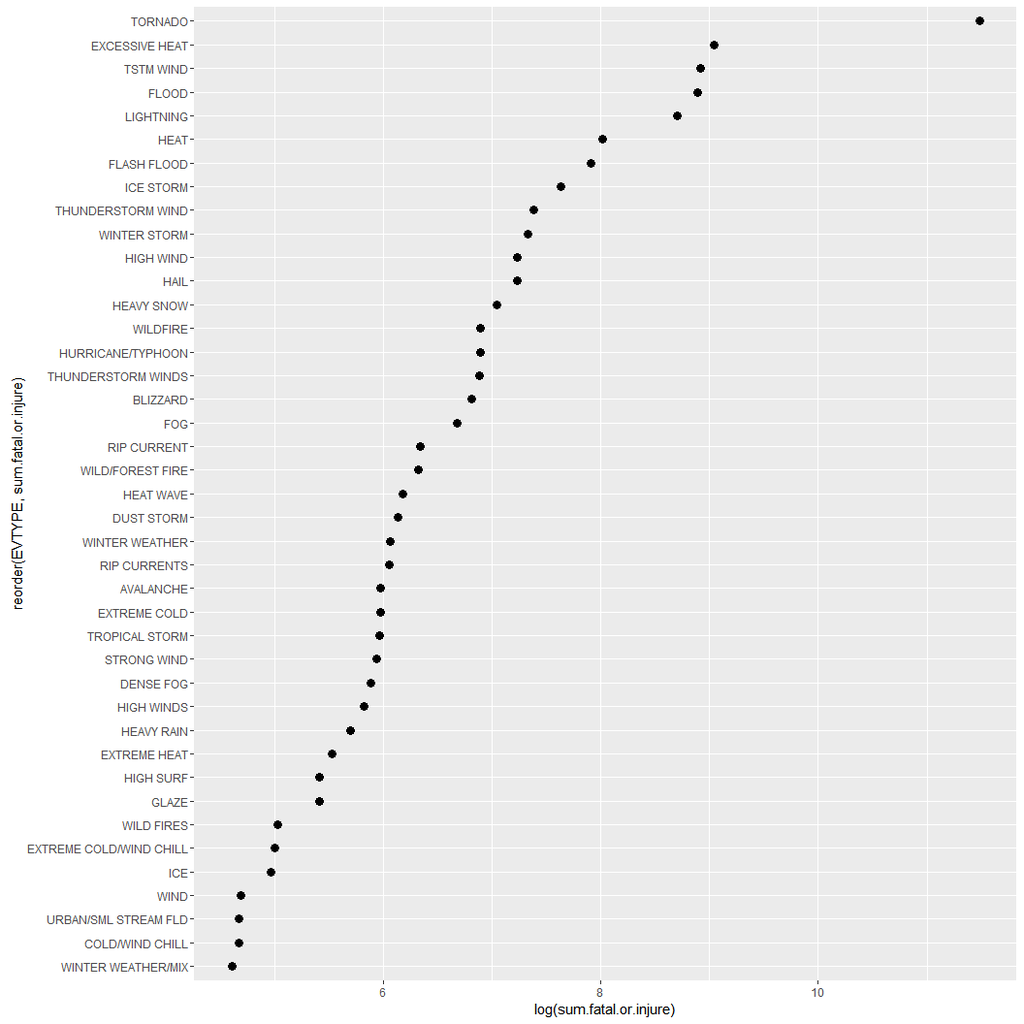

```r
a <- ggplot(dt_data_sums, aes(log(sum.fatal.or.injure), reorder(EVTYPE,sum.fatal.or.injure))) +
                geom_point(size=3)
print(a)
```

Tornado (by an order of magnitude), excessive heat, and thunderstorm (TSTM) wind are the top 3 injury and fatality events, since 1950. I’d like to plot all of the injury, fatality, and average data on the same plot, so I need to tidy the data. Data is ordered by sum.fatal.or.injure. I know it is going to deprecate my duplicate levels, this is ok for this plot.

```r
dt_data_sums %>% gather(type, count, -EVTYPE) -> tidy.data
nameorder <- tidy.data$EVTYPE[order(tidy.data[which(tidy.data$type == "sum.fatal.or.injure"),])]
tidy.data$EVTYPE <- factor(tidy.data$EVTYPE, levels = nameorder)
```

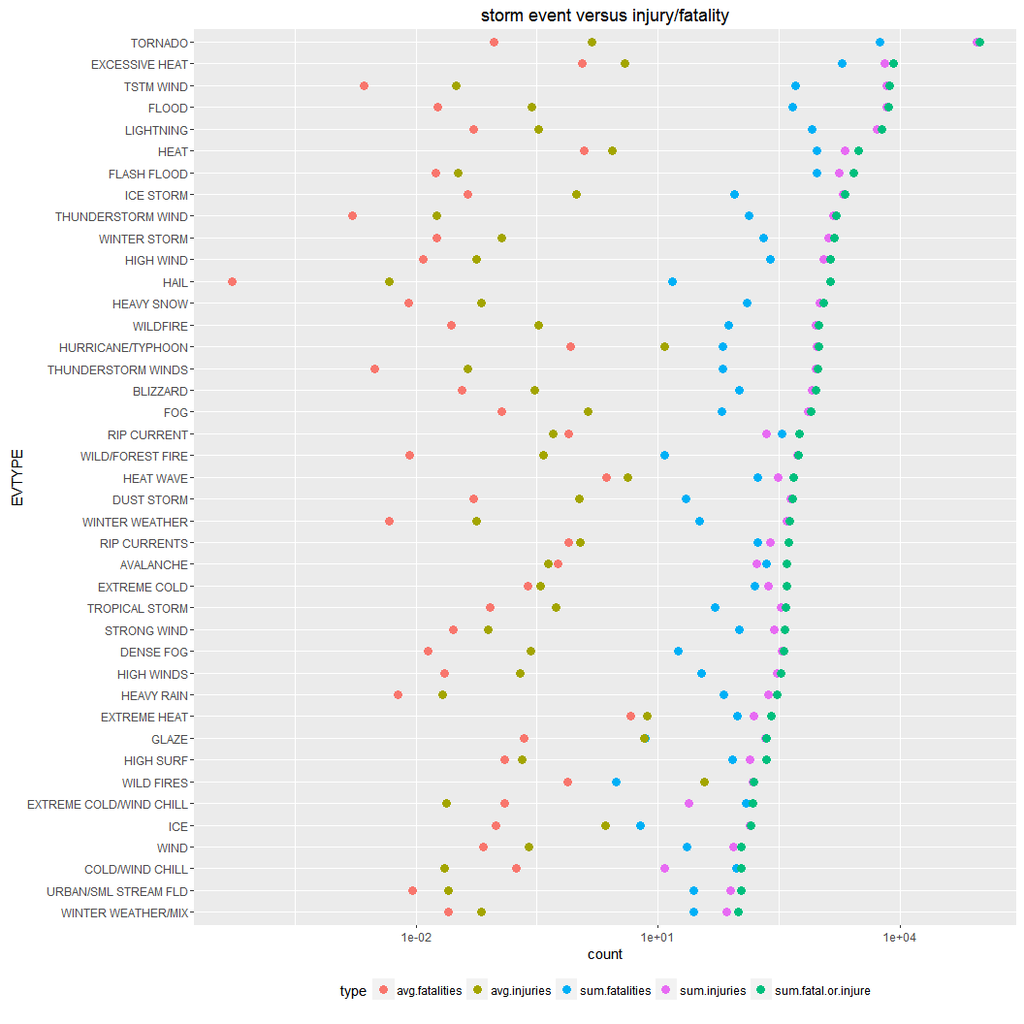

```r
b <- ggplot(tidy.data, aes(count, EVTYPE)) +
    geom_point(size=3, aes(colour=type)) +
         scale_colour_discrete(breaks=c("avg.fatalities", "avg.injuries", "sum.fatalities",
                                      "sum.injuries", "sum.fatal.or.injure")) +
    scale_x_log10() +
    theme(legend.position="bottom") +
    ggtitle("storm event versus injury/fatality")
print(b)
```

I love this dot plot! Clearly, tornado by itself is on top for the total historical sum.fatal.or.injure metric. However, if you study the avgerage injuries (olive green) and avgerage fatalities (red) dots you’ll see that all “heat” categories and hurricane/typhoon stand out above the baseline data. (“Glaze”" and “Wild Fires” also show elevated levels from baseline, but further down the chart.) This means that on average, when these events occur, they injure or kill more people than even tornados. But since 1950, tornados have injured or killed a larger total, likely do to a few signficantly bad events.

Top priority would be placed on tornados, heat, and hurricane/typhoons. I suspect heat would jump to the top of the list if we combined all 4 “heat” categories into a single line item.

### Economic Impact Analysis

Calculate: 1) Total sum and average values using PROPDMG and CROPDMG columns by event type. Even though CROPDMG is a separate column, I still consider it a direct economic impact event and can be combined with PROPDMG to examine overall economic impact. 2) Remove non-US states and rows with incorrect “EXP” sympols or values.

```r
## check for NA values
sum(is.na(dt_data_nonUS_removed$PROPDMG))
```

```
## [1] 0
```

```r
sum(is.na(dt_data_nonUS_removed$CROPDMG))
```

```
## [1] 0
```

```r
range(dt_data_nonUS_removed$PROPDMG) -> prop.damage.range
unique(dt_data_nonUS_removed$PROPDMGEXP) -> prop.damage.exp
range(dt_data_nonUS_removed$CROPDMG) -> crop.damage.range
unique(dt_data_nonUS_removed$CROPDMGEXP) -> crop.damage.exp
```

No NA rows. The exponent column is supposed to just have “B”, “M”, “K”, or “H”. I’d like to do a quick check on a few rows with the other values to figure out why they are there.

```r
dt_data_rows_wrong_exp <- dt_data_nonUS_removed[which(dt_data_nonUS_removed$PROPDMGEXP %in%
                                            c("+", "5", "6", "?", "4", "2", "3", "7", "-")),]
```

Is there a notes section at the bottom of the data? Why are numbers in the EXP column?

```r
tail(dt_data_nonUS_removed$PROPDMGEXP)
```

```
## [1] "K" "K" "K" "K" "K" "K"
```

```r
identical(crop.damage.exp, prop.damage.exp)
```

```
## [1] FALSE
```

```r
identical(dt_data_nonUS_removed$CROPDMGEXP, dt_data_nonUS_removed$PROPDMGEXP)
```

```
## [1] FALSE
```

It appears these numeric values are due to rounding not to 3 significant figures, or just incorrect input of data.

How many rows are like this?

```r
print(prop.damage.exp)
```

```
##  [1] "K" "M" ""  "B" "m" "+" "0" "5" "6" "?" "4" "2" "3" "h" "7" "H" "-"
## [18] "1" "8"
```

```r
print(crop.damage.exp)
```

```
## [1] ""  "M" "K" "m" "B" "?" "0" "k" "2"
```

```r
prop.damage.exp.incorrect <- prop.damage.exp[!prop.damage.exp %in%
                                                 c("K","M","B","m","h","H", "", "0")]

crop.damage.exp.incorrect <- crop.damage.exp[!crop.damage.exp %in%
                                                 c("k","K","M","B","m","h","H", "", "0")]

nrow(dt_data_nonUS_removed[which(dt_data_nonUS_removed$PROPDMGEXP %in%
                                                            prop.damage.exp.incorrect),])
```

```
## [1] 98
```

```r
nrow(dt_data_nonUS_removed[which(dt_data_nonUS_removed$CROPDMGEXP %in%
                                                            crop.damage.exp.incorrect),])
```

```
## [1] 8
```

98+8 rows with incorrect EXP values….ok, not many. I am going to remove them from the analysis.

Now I am going to filter out the rows that contain incorrect “EXP” values. Go back to original dt_data_nonUS_removed.

```r
dt_data_w_exp_rows_removed <- dt_data_nonUS_removed[which(!dt_data_nonUS_removed$PROPDMGEXP %in%
                                           prop.damage.exp.incorrect),]
dt_data_w_exp_rows_removed <- dt_data_w_exp_rows_removed[which
                                            (!dt_data_w_exp_rows_removed$CROPDMGEXP %in%
                                                crop.damage.exp.incorrect),]

print(unique(dt_data_w_exp_rows_removed$PROPDMGEXP))
```

```
## [1] "K" "M" ""  "B" "m" "0" "h" "H"
```

```r
print(unique(dt_data_w_exp_rows_removed$CROPDMGEXP))
```

```
## [1] ""  "M" "K" "m" "B" "0" "k"
```

OK, good, we removed the rows with incorrect “EXP” values. Now, create a function to translate character mulitpliers into numeric.

```r
exp.magnitude <- function(x) {
    ifelse(x == "K", 10^3,
    ifelse(x == "M", 10^6,
    ifelse(x == "" , 1,
    ifelse(x == "B", 10^9,
    ifelse(x == "m", 10^6,
    ifelse(x == "0" , 1,
    ifelse(x == "h", 10^2,
    ifelse(x == "H", 10^2, NA))))))))
}
```

Create the new columns with numeric multiplier, execute the multiplication, create a prop+crop summary column.

```r
dt_data_w_exp_rows_removed[ , prop.damage.multiplier := exp.magnitude(PROPDMGEXP)]
dt_data_w_exp_rows_removed[ , crop.damage.multiplier := exp.magnitude(CROPDMGEXP)]

dt_data_w_exp_rows_removed[ , prop.damage.total := prop.damage.multiplier*PROPDMG]
dt_data_w_exp_rows_removed[ , crop.damage.total := crop.damage.multiplier*CROPDMG]
dt_data_w_exp_rows_removed[ , damage.total := prop.damage.total+crop.damage.total]
```

Now generate the statistics. Sum and averages for property and crop, plus sum/averages for prop+crop, all by event type. Since I am plotting on a dot plot, I filtered out rows to make the plot readable.

```r
dt_data_econ <- dt_data_w_exp_rows_removed[ ,.(sum.property=sum(prop.damage.total),
                                               avg.property=mean(prop.damage.total),
                                         sum.crop=sum(crop.damage.total),
                                         avg.crop=mean(crop.damage.total),
                                         sum.prop.and.crop=sum(damage.total)),
                                      by=EVTYPE][order(-sum.prop.and.crop)][sum.prop.and.crop >100000000]

dt_data_econ
```

```
##                         EVTYPE sum.property avg.property    sum.crop
##  1:                      FLOOD 144541318807 5.789063e+06  5613968450
##  2:          HURRICANE/TYPHOON  69033100000 8.965338e+08  2603500800
##  3:                    TORNADO  56936690617 9.391619e+05   414952270
##  4:                STORM SURGE  43323536000 1.659906e+08        5000
##  5:                FLASH FLOOD  15884265329 2.979492e+05  1406475100
##  6:                    DROUGHT   1041106000 4.211594e+05 13972366000
##  7:                  HURRICANE   9913998010 7.343702e+07  2189930000
##  8:                RIVER FLOOD   5118942000 3.179467e+07  5029459000
##  9:                  ICE STORM   3944927860 1.966564e+06  5022113500
## 10:             TROPICAL STORM   7602721550 1.224271e+07   573995000
## 11:               WINTER STORM   6688497251 5.850168e+05    26944000
## 12:                  HIGH WIND   5269120260 2.610543e+05   638297300
## 13:                   WILDFIRE   4759329000 1.741430e+06   295307800
## 14:                  TSTM WIND   4469633495 2.032649e+04   554007350
```

[output cut: 89 more lines]

I’d like to plot all of the property, crop, and combined data on the same plot, so I need to tidy the data. Data is ordered by sum.prop.and.crop. I know it is going to deprecate my duplicate levels, this is ok for this plot.

```r
dt_data_econ %>% gather(type, count, -EVTYPE) -> tidy.econ.data
nameorder <- tidy.econ.data$EVTYPE[order(tidy.econ.data[which(tidy.econ.data$type == "sum.prop.and.crop"),])]
tidy.econ.data$EVTYPE <- factor(tidy.econ.data$EVTYPE, levels = nameorder)
```

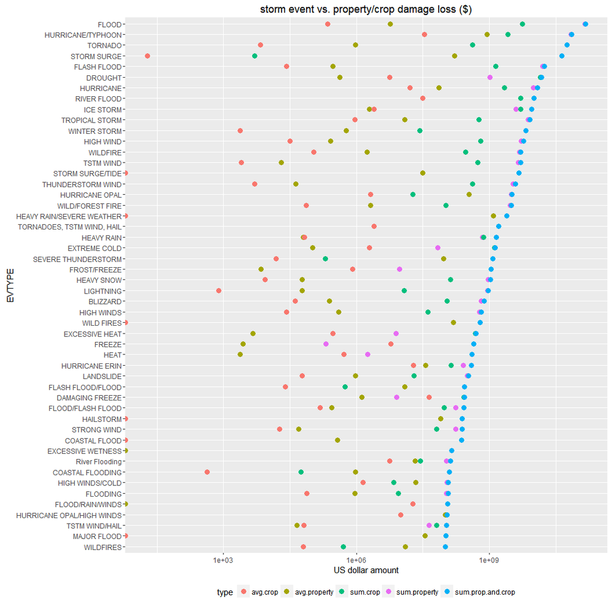

```r
b <- ggplot(tidy.econ.data, aes(count, EVTYPE)) +
    geom_point(size=3, aes(colour=type)) +
    scale_x_log10() +
         scale_color_discrete(breaks=c("avg.crop", "avg.property", "sum.crop",
                                       "sum.property", "sum.prop.and.crop")) +
    xlab("US dollar amount") +
    theme(legend.position="bottom") +
    ggtitle("storm event vs. property/crop damage loss ($)")
print(b)
```

The top 3 economic impact over the measured 61 years are: 1) flood, 2) hurricane/typhoon, and 3) tornado. It is interesting to note that the majority of economic loss is in property, evidenced by the overlap of the sum.property (pink) and sum.prop.and.crop (blue) datapoints for most events. Temperature related events (drought, extreme heat/cold, frost) all show higher total crop damage (green) than total property damage (pink) - this intuitively makes sense. The catastropic events like flood, hurricane/typhoon, tornados are the events that cause the largest property damage.